# Companion notebook: Weather Data Lives on a Sphere

This notebook reproduces **every figure and every benchmark number** in the article *Weather Data Lives on a Sphere. Our Statistics Should Too.*

It is a thin, auditable layer over the repository's scripts: nothing here is reimplemented, each cell calls the same code the article used.

**Quick mode (default).** The two ERA5 cells reuse the cached netCDF files shipped alongside this notebook (`era5_heatdome_2021.nc`, `era5_jja_monthly_1991_2020.nc`), so no API key is needed. If the cached files are missing, the scripts fall back to downloading from the Copernicus Climate Data Store, which requires a free CDS account and an API token in `~/.cdsapirc` (see the ERA5 section below).

Sections: 1. environment, 2. validation benchmarks, 3. property figures, 4. ERA5 applications.

## 1. Environment and versions

```python
import sys
from importlib.metadata import version

print("python     ", sys.version.split()[0])
for pkg in ["numpy", "geomstats", "matplotlib", "xarray", "cdsapi"]:
    print(f"{pkg:<11}", version(pkg))
```

```
python      3.12.3
numpy       2.0.2
geomstats   2.8.0
matplotlib  3.11.0
xarray      2026.4.0
cdsapi      0.7.7
```

## 2. Validation benchmarks (the article's validation box)

Real weather has no planted ground truth, so correctness is checked on synthetic data with a known answer. Each line below states the property being tested and the measured result. These are the numbers quoted in the article.

### 2.1 Frechet mean (tracking engine)

B1 analytic ground truth, B2 agreement with GeomStats (after tightening its optimizer, whose default stops about 2.7 km short), B3 first-order optimality, B4 chordal-vs-geodesic gap growth, B5 date-line failure of the naive mean plus SO(3) equivariance, B6 planted trajectory recovery.

```python
import tool1_centroid_tracker as tool1

tool1.bench()
```

```
B1  Recover a vMF blob's known center (analytic ground truth)
[PASS] frechet recovers center      truth=(35.0, -100.0) got=(35.000,-100.000) err=0.00 km

B2  Hand-rolled Karcher == GeomStats FrechetMean
[PASS] karcher vs geomstats         geodesic gap = 1.90e-04 km

B3  First-order optimality: ||sum w_i log_mu(p_i)|| ~ 0
[PASS] gradient residual ~ 0        residual = 5.99e-16

B4  Chordal (naive) vs geodesic (Frechet) gap grows with SPREAD
      (a symmetric blob has gap 0 by symmetry - local flatness; the gap
       appears only for asymmetric/spread data, as in figure 6 / hello_sphere)
      tight cluster   spread_radius=  3.1 deg  chordal-vs-geodesic gap =      0.0 km
      continental     spread_radius= 33.4 deg  chordal-vs-geodesic gap =     40.7 km
      global spread   spread_radius= 93.5 deg  chordal-vs-geodesic gap =   7758.9 km

B5  Dateline + SO(3) equivariance
[PASS] frechet ok at dateline       err = 0.00 km
[PASS] naive latlon FAILS           err = 17805 km  (avg lon -> 0.0 deg, wrong side)
[PASS] SO(3)-equivariant            invariance error = 9.49e-05 km

B6  Recover a MOVING planted trajectory (10 days)
```

```
[PASS] trajectory recovered         max_err=0.00 km  total_path=5802 km
```

### 2.2 Principal Geodesic Analysis (variability engine)

B1 planted-axis recovery, B2 agreement with GeomStats `TangentPCA`, B3 no spurious axis on isotropic data, B4 PGA versus naive lat/long PCA near a pole, B5 one-axis reconstruction error, B6 SO(3) equivariance of the axes.

```python
import tool3_geodesic_pca as tool3

tool3.bench()
```

```
B1  Recover a planted principal axis (ground truth)
[PASS] axis recovered                 axis within 0.73 deg; captured 97.5% variance; mean off 69 km

B2  Hand-rolled == GeomStats TangentPCA (integrity)
[PASS] matches library                axis angle diff 0.00e+00 deg; var-ratio diff 3.33e-16

B3  Isotropic -> no spurious axis; anisotropic -> real axis
[PASS] isotropic ratio ~ 1            lambda1/lambda2 = 1.38
[PASS] anisotropic ratio high         lambda1/lambda2 = 75.3

B4  PGA vs naive lat/long PCA near a pole (why geometry)
[PASS] PGA axis correct at pole       PGA off 0.8 deg
[PASS] naive lat/long axis wrong      naive off 39.2 deg  (a 51x worse axis)

B5  1-axis reconstruction error (justifies dimensionality reduction)
[PASS] 1 axis reconstructs cloud      RMS geodesic error 306 km  (cloud spread 53 deg)

B6  SO(3) equivariance (coordinate-free)
[PASS] axes rotate with the data      axis angle diff 0.00e+00 deg; var-ratio diff 4.44e-16
```

## 3. Property figures

### 3.1 Geometry: the naive-vs-geodesic gap grows with spread (article Figure 1)

```
saved spread_gap.png
  tight cluster   spread   3.1 deg   gap      0.0 km
  continental     spread  33.4 deg   gap     40.7 km
  global spread   spread  93.5 deg   gap   7758.9 km
```

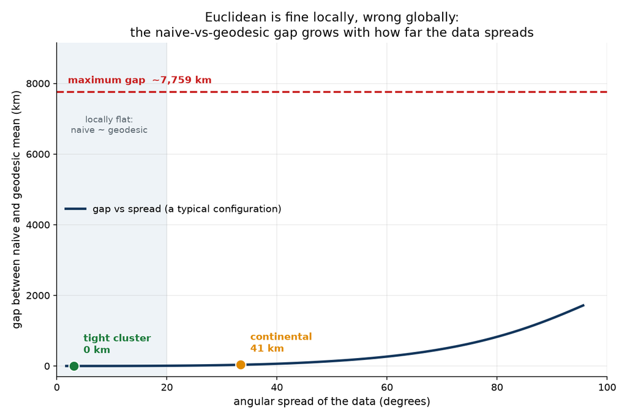

```python
from IPython.display import Image, display
import spread_gap_figure

spread_gap_figure.make()
display(Image("spread_gap.png", width=700))
```

### 3.2 Algebra: the Frechet mean is SO(3)-equivariant, the naive mean is not (article Figure 2)

```
left  mean (lat,lon):  Frechet (np.float64(22.0), np.float64(-100.6))   naive drift 15 km
right mean (lat,lon):  Frechet (86.0,-108.0)   naive drift 782 km
equivariance error  |mu(R.X) - R.mu(X)| = 0.00013 km
```

```
saved equivariance.png
```

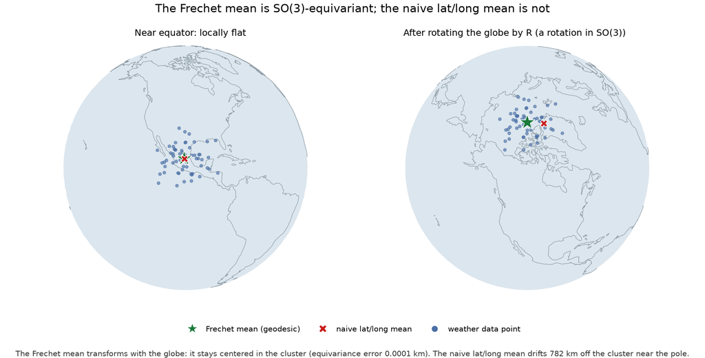

```python
import equivariance_figure

equivariance_figure.make()
display(Image("equivariance.png", width=850))
```

## 4. ERA5 applications

**Data source.** ERA5 is the ECMWF global reanalysis, distributed by the Copernicus Climate Data Store (CDS). The two cells below use:

- hourly 2 m temperature, June 24-30 2021, over a North America window (`era5_heatdome_2021.nc`, about 0.3 MB);
- monthly-mean 2 m temperature, June-August 1991-2020, over a North America window (`era5_jja_monthly_1991_2020.nc`, about 4.5 MB).

If these cached files are present the cells run offline. Otherwise the scripts download them once via `cdsapi`, which needs a free CDS account, a Personal Access Token in `~/.cdsapirc`, and acceptance of the ERA5 licence on the dataset page. Credentials are never stored in this repository.

### 4.1 Tracking the June 2021 heat dome (article Figure 3)

```
using cached era5_heatdome_2021.nc
```

```
day         Frechet (lat,lon)       naive (lat,lon)           gap km
2021-06-24  ( 34.27,-103.57)     ( 34.11,-103.51)       18.3
2021-06-25  ( 33.25,-106.78)     ( 33.08,-106.82)       19.8
2021-06-26  ( 35.48,-112.04)     ( 35.29,-112.35)       34.7
2021-06-27  ( 38.81,-116.67)     ( 38.74,-116.97)       27.1
2021-06-28  ( 40.88,-117.52)     ( 40.82,-117.80)       24.3
2021-06-29  ( 44.60,-117.72)     ( 44.57,-117.88)       13.0
2021-06-30  ( 49.34,-114.99)     ( 49.26,-114.67)       24.7

total Frechet centroid migration: 2635 km over 7 days
```

```
saved era5_heatdome.png
```

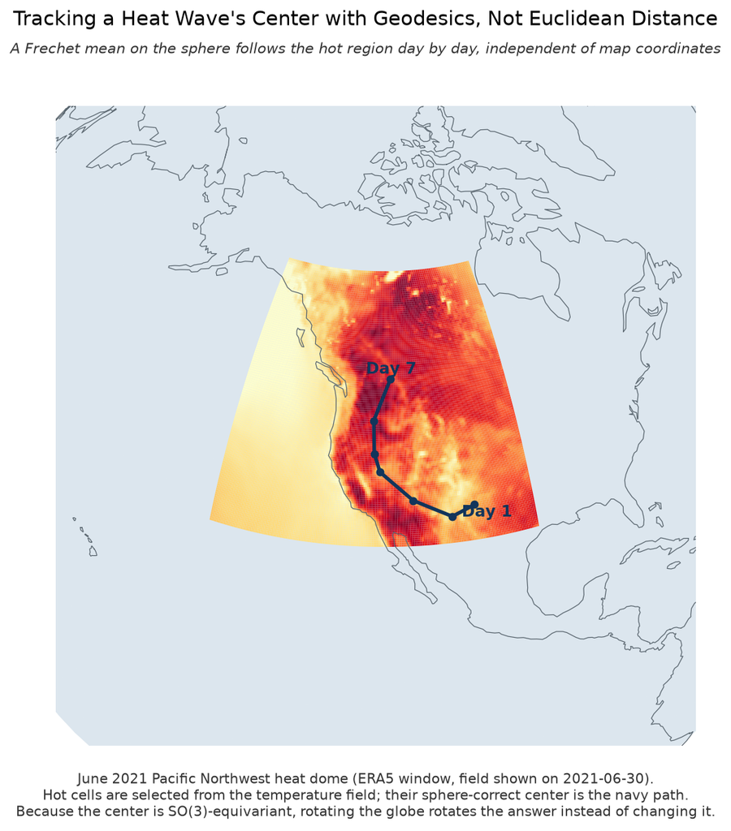

```python
import era5_heatwave as heatwave

data = heatwave.load(heatwave.fetch())   # cached .nc if present
rows = heatwave.track(data)
heatwave.print_report(rows)
heatwave.plot(data, rows)
display(Image("era5_heatdome.png", width=650))
```

### 4.2 Interannual variability of summer heat, 1991-2020 (article Figure 4)

One anomaly heat-center per summer (that year's JJA mean minus the 30-year climatology), then PGA on the 30 centers.

```
using cached era5_jja_monthly_1991_2020.nc
```

```
year    heat-anomaly center (lat, lon)
1991    ( 52.67,  -94.25)
1992    ( 34.22, -120.20)
1993    ( 38.47,  -87.77)
1994    ( 40.17, -112.08)
1995    ( 45.90,  -86.75)
1996    ( 44.77, -109.29)
1997    ( 36.31, -123.07)
1998    ( 48.67,  -96.92)
1999    ( 52.05,  -83.52)
2000    ( 41.45, -105.60)
2001    ( 48.89,  -96.40)
2002    ( 43.14,  -98.23)
2003    ( 48.15, -109.89)
2004    ( 48.90, -126.22)
```

[output cut: 21 more lines]

```
saved era5_pga_interannual.png
```

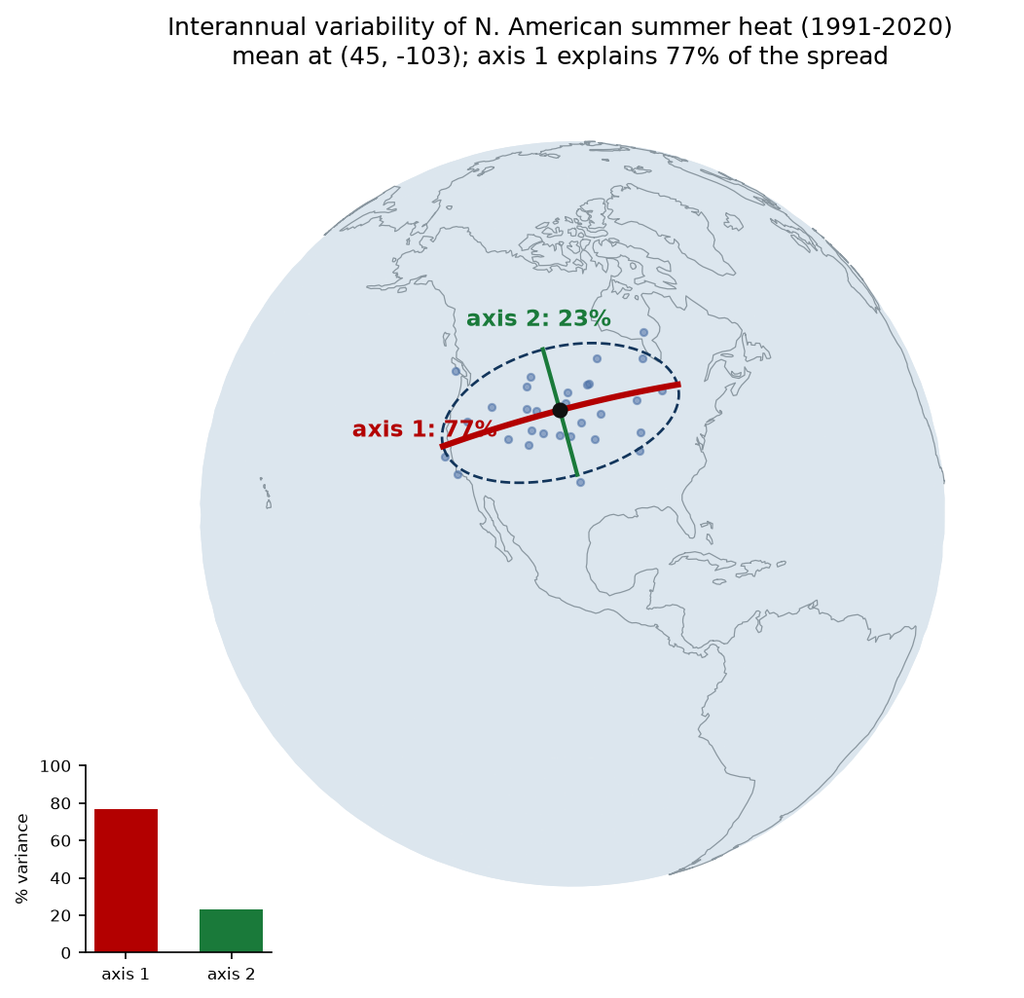

```python
import era5_pga_interannual as interannual
from tool3_geodesic_pca import GeodesicPCA

data30 = interannual.load(interannual.fetch())   # cached .nc if present
centers = interannual.yearly_centroids(data30)
pga = GeodesicPCA().fit(centers)
interannual.report(data30, centers, pga)
interannual.plot_pga(pga, centers, png="era5_pga_interannual.png",
                     title="Interannual variability of N. American summer heat (1991-2020)")
display(Image("era5_pga_interannual.png", width=650))
```

That is the complete evidence base of the article: two benchmark suites, two property figures, two real-data applications. Methods are Karcher (1977) and Fletcher et al. (2004) as surveyed in Papillon, Sanborn, Mathe et al., *Beyond Euclid* (2025), computed with GeomStats.